# Analysis of pH at Three Sites

Ryan Wang

9/3/2022

## Handling the missing data: Take lompoc landing part as an example.

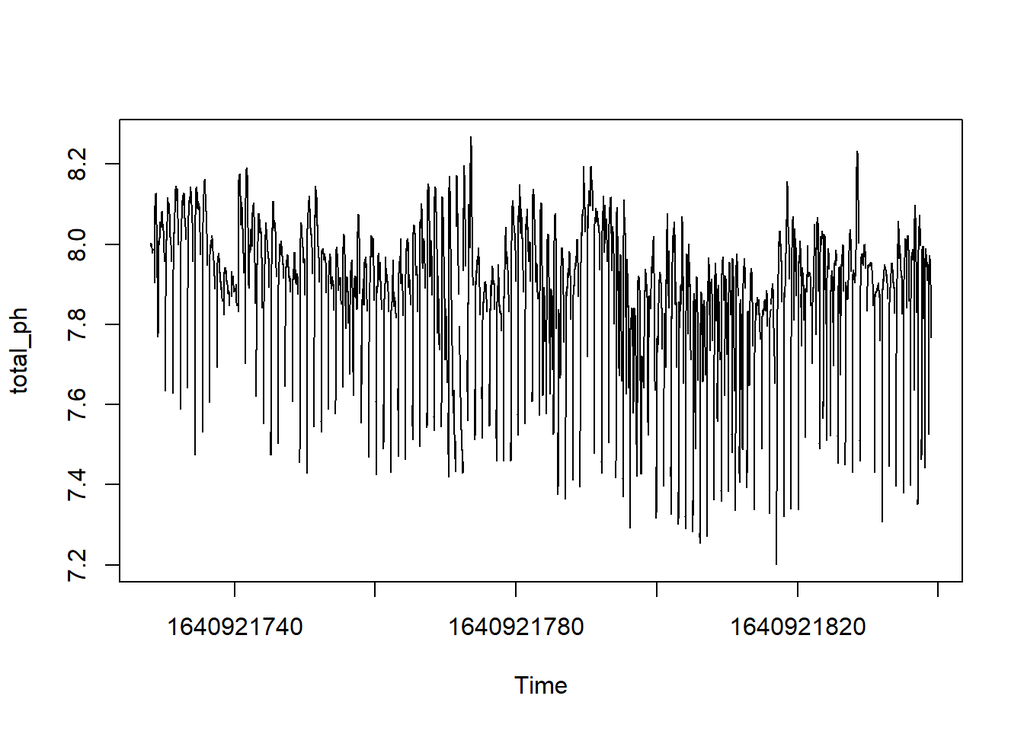

```r
lol_na<-read.csv('C:/Users/Ryan_/Documents/R/pH_timeseries/lol_incomplete.csv')
total<-read.csv('C:/Users/Ryan_/Documents/R/time series/files/total.csv')
lol_ph<-total[,c(2,4)]

y=strptime("2021-06-18 1:15:00","%Y-%m-%d %H:%M:%S")+900*1:10643
total_ph=ts(lol_ph[,2],y, frequency = 96)
total_ph1=ts(lol_ph[,2],y, frequency = 1)
plot(total_ph)
```

```r
# Summary stats about the distribution of missing values
statsNA(total_ph)
```

```
## [1] "Length of time series:"
## [1] 10643
## [1] "-------------------------"
## [1] "Number of Missing Values:"
## [1] 2213
## [1] "-------------------------"
## [1] "Percentage of Missing Values:"
## [1] "20.8%"
## [1] "-------------------------"
## [1] "Number of Gaps:"
## [1] 124
## [1] "-------------------------"
## [1] "Average Gap Size:"
## [1] 17.84677
## [1] "-------------------------"
```

[output cut: 42 more lines]

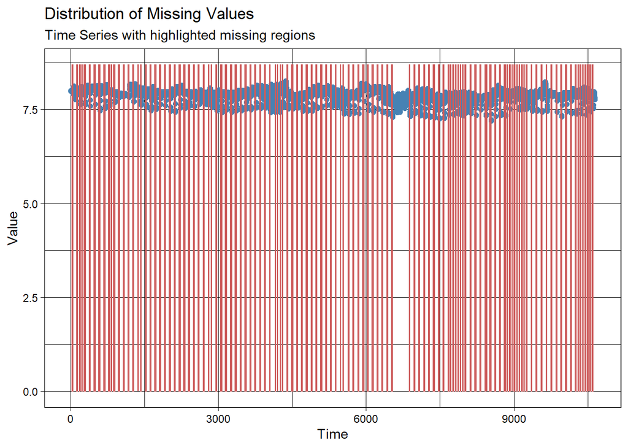

```r
ggplot_na_distribution(total_ph)
```

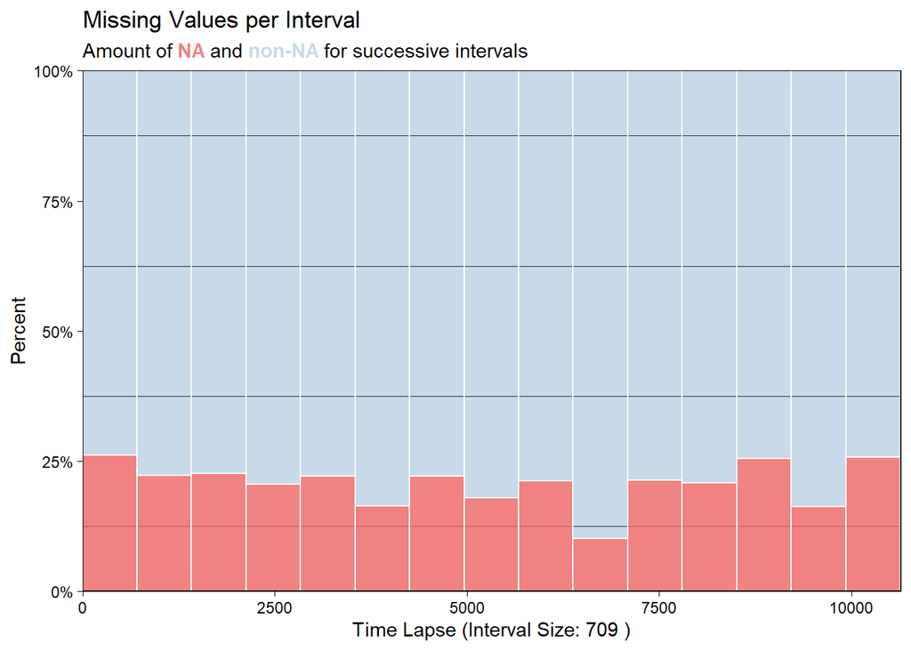

```r
# Visualize the missing values in this time series
ggplot_na_intervals(total_ph)
```

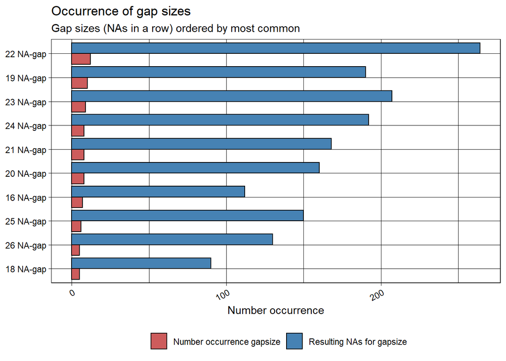

```r
# Visualize the top gap sizes / NAs in a row
ggplot_na_gapsize(total_ph)
```

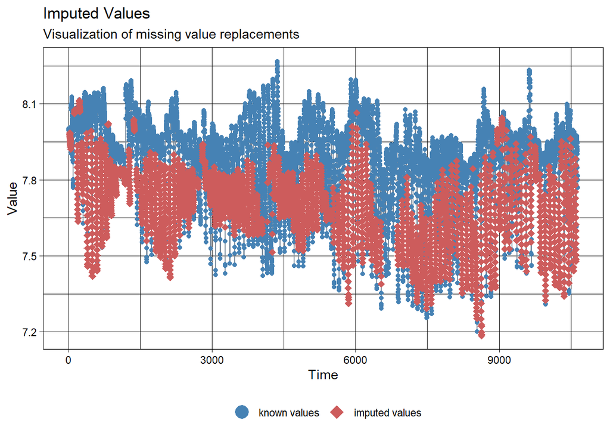

```r
# Imputation by auto.arima
lol_ph$imp <- na_kalman(total_ph1, model = "auto.arima")
ggplot_na_imputations(total_ph, lol_ph$imp)
```

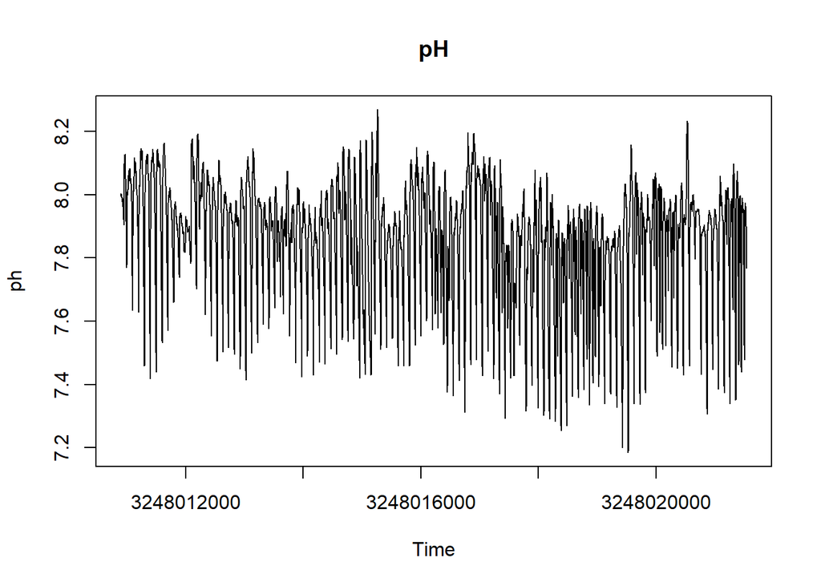

```r
# Seasonal Adjustment then Imputation by Last Observation Carried Forward
lol_ph$ph_s_locf<-na_seadec(total_ph, algorithm = "locf")

ph<-lol_ph$imp
ph1<-lol_ph$ph_s_locf
plot(ph, main = "pH")
```

Similarly, there are missing pH values in Algeria and Bodega Bay parts. The missing values are filled with the same technique.

## Load the data with no missing values.

```r
lol<-read.csv('C:/Users/Ryan_/Documents/R/pH_timeseries/Lompoc Landing.csv')
ala<-read.csv('C:/Users/Ryan_/Documents/R/pH_timeseries/Algeria.csv')
bob<-read.csv('C:/Users/Ryan_/Documents/R/pH_timeseries/Bodega Bay.csv')
```

### Visualization of the data

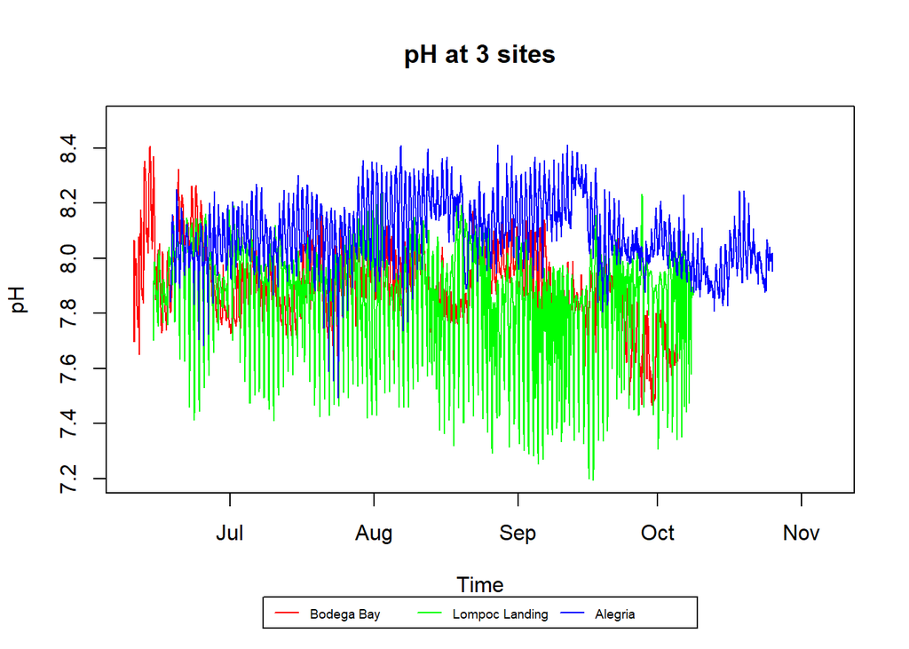

```r
# convert the data into time series form
bob_x <- strptime("2021-06-10 06:15:00","%Y-%m-%d %H:%M:%S")+900*1:nrow(bob)
lol_x <- strptime("2021-06-14 11:30:00","%Y-%m-%d %H:%M:%S")+900*1:nrow(lol)
ala_x <- strptime("2021-06-18 1:15:00","%Y-%m-%d %H:%M:%S")+900*1:nrow(ala)
bob_power <- zoo(bob[,3],bob_x)
lol_power <- zoo(lol[,3],lol_x)
ala_power <- zoo(ala[,3],ala_x)


# pH at 3 sites.
par(mar = c(6, 4.1, 4.1, 2.1))
plot(bob_power,col="red",ylim=c(7.2,8.5),xlab="Time",ylab="pH",main = 'pH at 3 sites',
     xlim=c(as.POSIXct(strptime("2021-06-10 06:15:00","%Y-%m-%d %H:%M:%S")),
            as.POSIXct(strptime("2021-11-06 09:15:00","%Y-%m-%d %H:%M:%S"))))
lines(lol_power,col="green")
lines(ala_power,col="blue")
legend("bottom", inset = c(0, -0.35),
       xpd = TRUE,
       legend = c("Bodega Bay","Lompoc Landing","Alegria"),
       col = c("red","green","blue"),
       lty=1,
       horiz=TRUE,
       cex=0.6,
       xjust=0.5)
```

```r
# classify the columns by date/week/season/hour in one day
bob$day <-as.Date(mdy_hm(bob$date_time))
bob$week <- week(bob$day)
bob$month <- month(bob$day)
bob$Q <- ifelse(bob$month %in% c(6,7,8),2,3) # if the month is June, July, August, then it is the 2nd quarter. Otherwise, it is the 3rd quarter.
bob$hour <- hour(mdy_hm(bob$date_time))

lol$day <- as.Date(mdy_hm(lol$date_time))
lol$week <- week(lol$day)
lol$month <- month(lol$day)
lol$Q <- ifelse(lol$month %in% c(6,7,8),2,3)
lol$hour <- hour(mdy_hm(lol$date_time))

ala$day <- as.Date(mdy_hm(ala$date_time))
ala$week <- week(ala$day)
ala$month <- month(ala$day)
ala$Q <- ifelse(ala$month %in% c(6,7,8),2,3)
ala$hour <- hour(mdy_hm(ala$date_time))

# Calculate the mean pH values that are classified in different ways

bob_day_mean <- aggregate(p_h~day,data = bob,FUN = mean) # each day's mean value of pH
bob_week_mean <- aggregate(p_h~week,data = bob,FUN = mean) # each week's mean value of pH
bob_hour_mean <- aggregate(p_h~Q+hour,data = bob,FUN = mean)# each hour's mean value of pH, classfied by month
bob_month_mean <- aggregate(p_h~month,data = bob,FUN = mean)# each month's mean value of pH

lol_day_mean <- aggregate(p_h~day,data = lol,FUN = mean)
lol_week_mean <- aggregate(p_h~week,data = lol,FUN = mean)
lol_hour_mean <- aggregate(p_h~Q+hour,data = lol,FUN = mean)
lol_month_mean <- aggregate(p_h~month,data = lol,FUN = mean)

ala_day_mean <- aggregate(p_h~day,data = ala,FUN = mean)
ala_week_mean <- aggregate(p_h~week,data = ala,FUN = mean)
ala_hour_mean <- aggregate(p_h~Q+hour,data = ala,FUN = mean)
ala_month_mean <- aggregate(p_h~month,data = ala,FUN = mean)
```

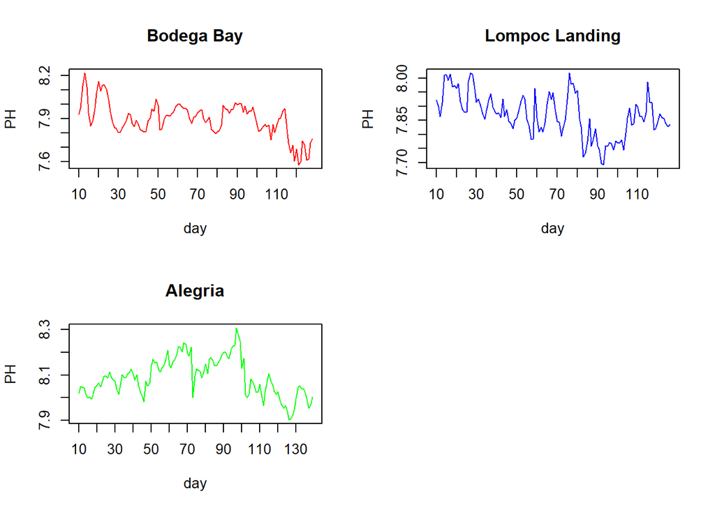

```r
# averaging across day
par(mfrow = c(2, 2))
plot(bob_day_mean,type="l",xaxt = "n",main="Bodega Bay",
     xlab="day",ylab="PH",col="red")
axis(1, at=seq(min(bob_day_mean$day),max(bob_day_mean$day),by = 10),
     labels=seq(10,120,10))

plot(lol_day_mean,type="l",xaxt = "n",main="Lompoc Landing",
     xlab="day",ylab="PH",col="blue")
axis(1, at=seq(min(lol_day_mean$day),max(lol_day_mean$day),by = 10),
     labels=seq(10,120,10))

plot(ala_day_mean,type="l",xaxt = "n",main="Alegria",
     xlab="day",ylab="PH",col="green")
axis(1, at=seq(min(ala_day_mean$day),max(ala_day_mean$day),by = 10),
     labels=seq(10,130,10))

# averaging across week
par(mfrow = c(2, 2))
```

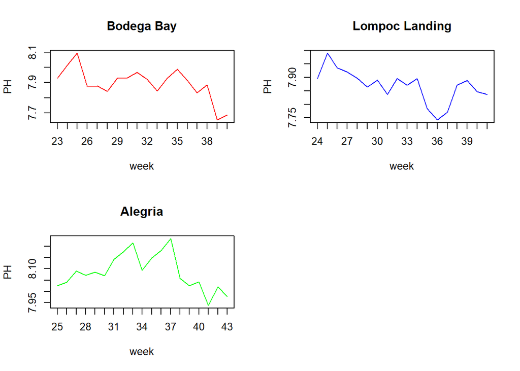

```r
plot(bob_week_mean,type="l",xaxt = "n",main="Bodega Bay",
     xlab="week",ylab="PH",col="red")
axis(1, at=seq(min(bob_week_mean$week),max(bob_week_mean$week),by = 1),
     labels=seq(23,40,1))

plot(lol_week_mean,type="l",xaxt = "n",main="Lompoc Landing",
     xlab="week",ylab="PH",col="blue")
axis(1, at=seq(min(lol_week_mean$week),max(lol_week_mean$week),by = 1),
     labels=seq(24,41,1))

plot(ala_week_mean,type="l",xaxt = "n",main="Alegria",
     xlab="week",ylab="PH",col="green")
axis(1, at=seq(min(ala_week_mean$week),max(ala_week_mean$week),by = 1),
     labels=seq(25,43,1))

# averaging across month
par(mfrow = c(2, 2))
```

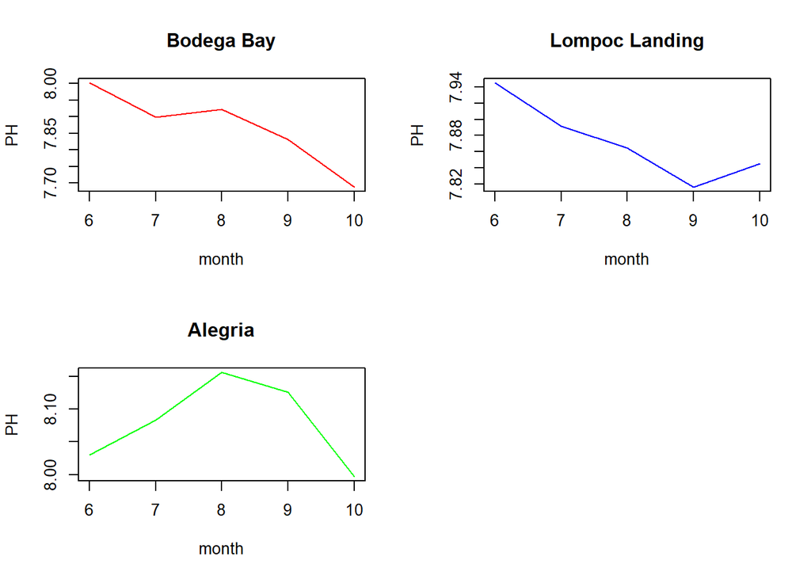

```r
plot(bob_month_mean,type="l",xaxt = "n",main="Bodega Bay",
     xlab="month",ylab="PH",col="red")
axis(1, at=seq(min(bob_month_mean$month),max(bob_month_mean$month),by = 1),
     labels=seq(6,10,1))

plot(lol_month_mean,type="l",xaxt = "n",main="Lompoc Landing",
     xlab="month",ylab="PH",col="blue")
axis(1, at=seq(min(lol_month_mean$month),max(lol_month_mean$month),by = 1),
     labels=seq(6,10,1))

plot(ala_month_mean,type="l",xaxt = "n",main="Alegria",
     xlab="month",ylab="PH",col="green")
axis(1, at=seq(min(ala_month_mean$month),max(ala_month_mean$month),by = 1),
     labels=seq(6,10,1))
```

Plots of trend of pH values by averaging across day/ averaging across week/ averaging across month.

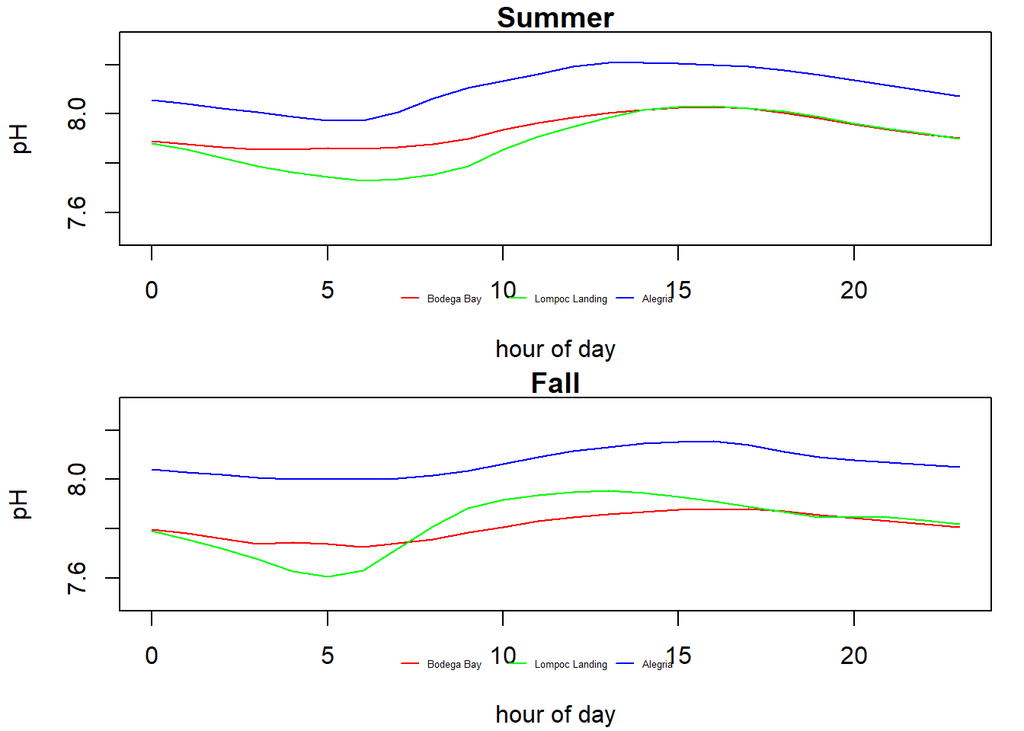

```r
par(mfrow = c(2, 1))
season <- c("Summer","Fall")
for (i in 2:3){
  par(mar = c(4.1, 4.1, 1.1, 1.1))
  plot(x=bob_hour_mean[bob_hour_mean$Q==i,"hour"],
       y=bob_hour_mean[bob_hour_mean$Q==i,"p_h"],
       col="red",xlab="hour of day",ylab="pH",
       ylim=c(7.5,8.3),main=season[i-1],type="l")
  lines(x=lol_hour_mean[lol_hour_mean$Q==i,"hour"],
        y=lol_hour_mean[lol_hour_mean$Q==i,"p_h"],
        col="green")
  lines(x=ala_hour_mean[ala_hour_mean$Q==i,"hour"],
        y=ala_hour_mean[ala_hour_mean$Q==i,"p_h"],
        col="blue")
  legend("bottom", inset = c(0.2, -0.3),
         legend = c("Bodega Bay","Lompoc Landing","Alegria"),
         col = c("red","green","blue"),bty = "n",
         lty=1,xpd = TRUE,horiz=TRUE,xjust=0.5,text.font = 18,cex = 0.4)
}
```

pH of each season by averaging across each hour of the day.

```r
# The original data is too large to analyze, so I subset the data.
set.seed(12)
ala_subset<- ala[sample(nrow(ala), 500), c(1, 3:5)]
lol_subset<- lol[sample(nrow(lol), 500), c(1, 3:5)]
bob_subset<- bob[sample(nrow(bob), 500), c(1, 3:5)]

total<- rbind(ala_subset, lol_subset, bob_subset) # combine the three dataframes.
```

## Use one-way ANOVA to compare the mean

Null hypothesis: The means of the pH of the three sites are equal. Alternative hypothesis: At least one means of the pH across the three sites are not equal to others.

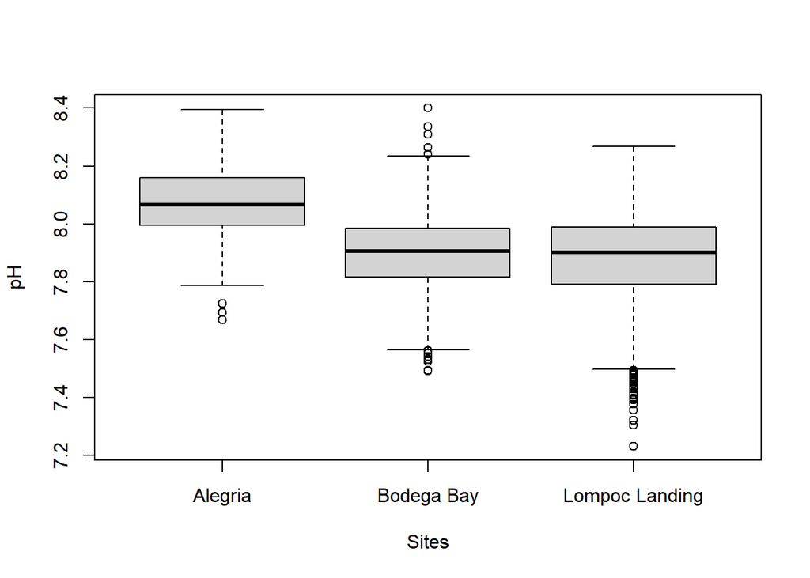

```r
boxplot(total$p_h~total$site, xlab = 'Sites', ylab = 'pH') # visualize data
```

```
## hat values (leverages) are all = 0.002
##  and there are no factor predictors; no plot no. 5
```

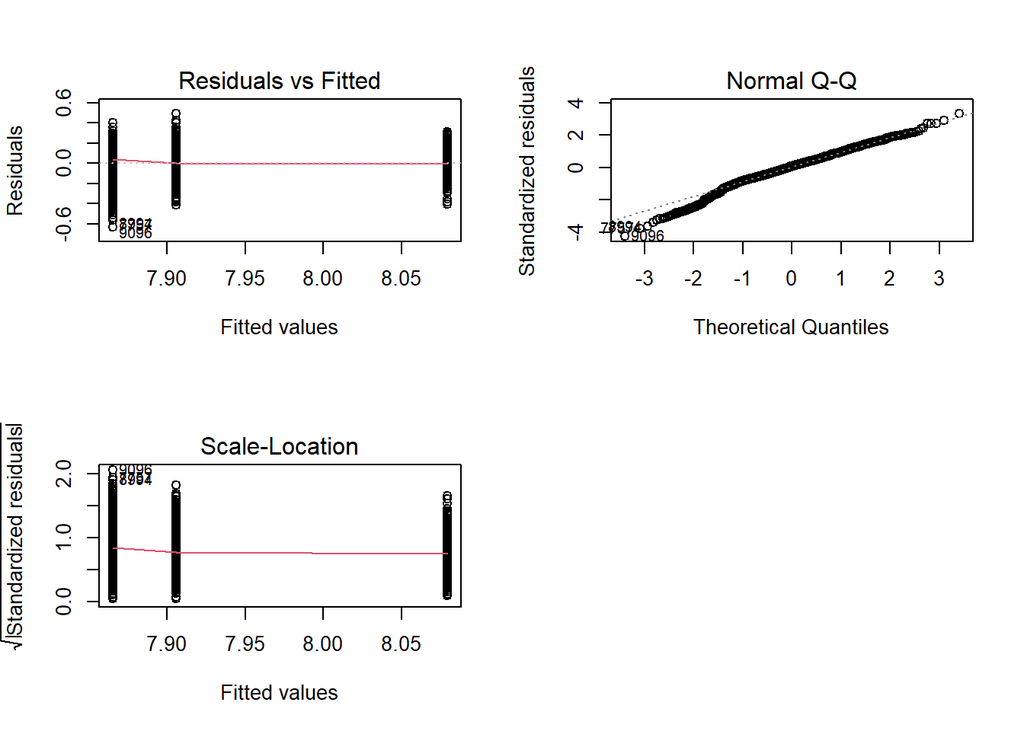

```r
ph_aov<-aov(total$p_h~total$site, data = total)
par(mfrow = c(2,2))
plot(ph_aov)
```

```r
leveneTest(total$p_h~total$site, data = total)
```

```
## Levene's Test for Homogeneity of Variance (center = median)
##         Df F value    Pr(>F)
## group    2  16.654 7.026e-08 ***
##       1497
## ---
## Signif. codes:  0 '***' 0.001 '**' 0.01 '*' 0.05 '.' 0.1 ' ' 1
```

```r
res_ph_aov <- ph_aov$residuals
qqPlot(res_ph_aov)
```

```
## 9096 7757
##  945  831
```

```r
shapiro.test(res_ph_aov) # test normality
```

```
##
##  Shapiro-Wilk normality test
##
## data:  res_ph_aov
## W = 0.98382, p-value = 6.178e-12
```

[figure not shown]

Check if the data meets the prerequisite of ANOVA test:

Use leveneTest to test equality of variance. Even though the levene’s test gives a low p-value, the residual vs. fitted plot shows no pattern and the predicted line is straight. So, I assume that the variances are the same Use shapiro-wilk test to test the normality of the residuals.

Even though the shapiro-wilk test gives a low p-value, the qqPlot shows that the most of the points lay inside the 95% confidence interval. So, I assume that the residuals are normal. Part of the reason why the test gives low p-value is that the size of the data is large.

```r
summary(ph_aov)
```

```
##               Df Sum Sq Mean Sq F value Pr(>F)
## total$site     2  12.86   6.428   289.6 <2e-16 ***
## Residuals   1497  33.23   0.022
## ---
## Signif. codes:  0 '***' 0.001 '**' 0.01 '*' 0.05 '.' 0.1 ' ' 1
```

```r
TukeyHSD(ph_aov)
```

```
##   Tukey multiple comparisons of means
##     95% family-wise confidence level
##
## Fit: aov(formula = total$p_h ~ total$site, data = total)
##
## $`total$site`
##                                  diff         lwr         upr    p adj
## Bodega Bay-Alegria        -0.17286152 -0.19496866 -0.15075438 0.00e+00
## Lompoc Landing-Alegria    -0.21353824 -0.23564538 -0.19143110 0.00e+00
## Lompoc Landing-Bodega Bay -0.04067672 -0.06278386 -0.01856958 5.01e-05
```

The p-value of the ANOVA is 2e-16, which is less than 0.05. So, I reject the null that the mean pH of site 1 = the mean pH of site 2 = the mean pH of site 3. The Tukey-Kramer test shows that the mean pH at the three sites are significantly different from one another.

Do the same to the temperature.

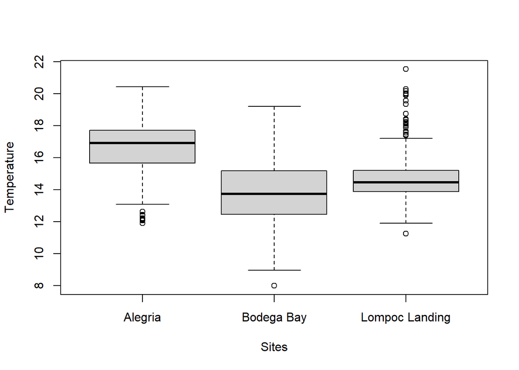

```r
boxplot(total$temp_c~total$site, xlab = 'Sites', ylab = 'Temperature') # visualize data
```

```
## hat values (leverages) are all = 0.002
##  and there are no factor predictors; no plot no. 5
```

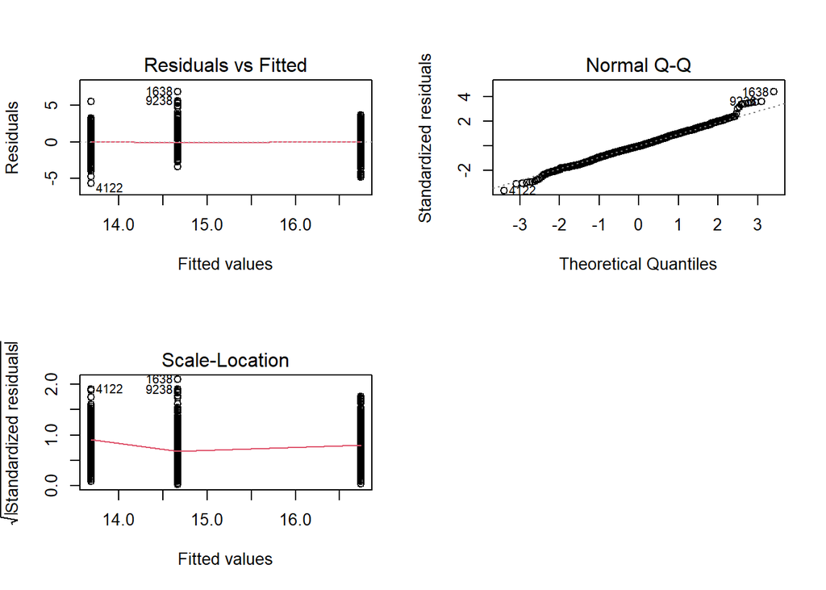

```r
temp_aov<-aov(total$temp_c~total$site, data = total)
par(mfrow = c(2,2))
plot(temp_aov)
```

```r
leveneTest(total$p_h~total$site, data = total)
```

```
## Levene's Test for Homogeneity of Variance (center = median)
##         Df F value    Pr(>F)
## group    2  16.654 7.026e-08 ***
##       1497
## ---
## Signif. codes:  0 '***' 0.001 '**' 0.01 '*' 0.05 '.' 0.1 ' ' 1
```

```r
res_temp_aov <- temp_aov$residuals
qqPlot(res_temp_aov)
```

```
## 1638 4122
##  785 1252
```

```r
shapiro.test(res_temp_aov)
```

```
##
##  Shapiro-Wilk normality test
##
## data:  res_temp_aov
## W = 0.99526, p-value = 0.000114
```

```r
summary(temp_aov)
```

```
##               Df Sum Sq Mean Sq F value Pr(>F)
## total$site     2   2437  1218.4   500.4 <2e-16 ***
## Residuals   1497   3645     2.4
## ---
## Signif. codes:  0 '***' 0.001 '**' 0.01 '*' 0.05 '.' 0.1 ' ' 1
```

```r
TukeyHSD(temp_aov)
```

```
##   Tukey multiple comparisons of means
##     95% family-wise confidence level
##
## Fit: aov(formula = total$temp_c ~ total$site, data = total)
##
## $`total$site`
##                                 diff        lwr       upr p adj
## Bodega Bay-Alegria        -3.0575478 -3.2890722 -2.826023     0
## Lompoc Landing-Alegria    -2.0753327 -2.3068571 -1.843808     0
## Lompoc Landing-Bodega Bay  0.9822151  0.7506907  1.213740     0
```

[figure not shown]

The Tukey-Kramer test shows that the mean temperature at the three sites are significantly different from one another.

## Test correlation

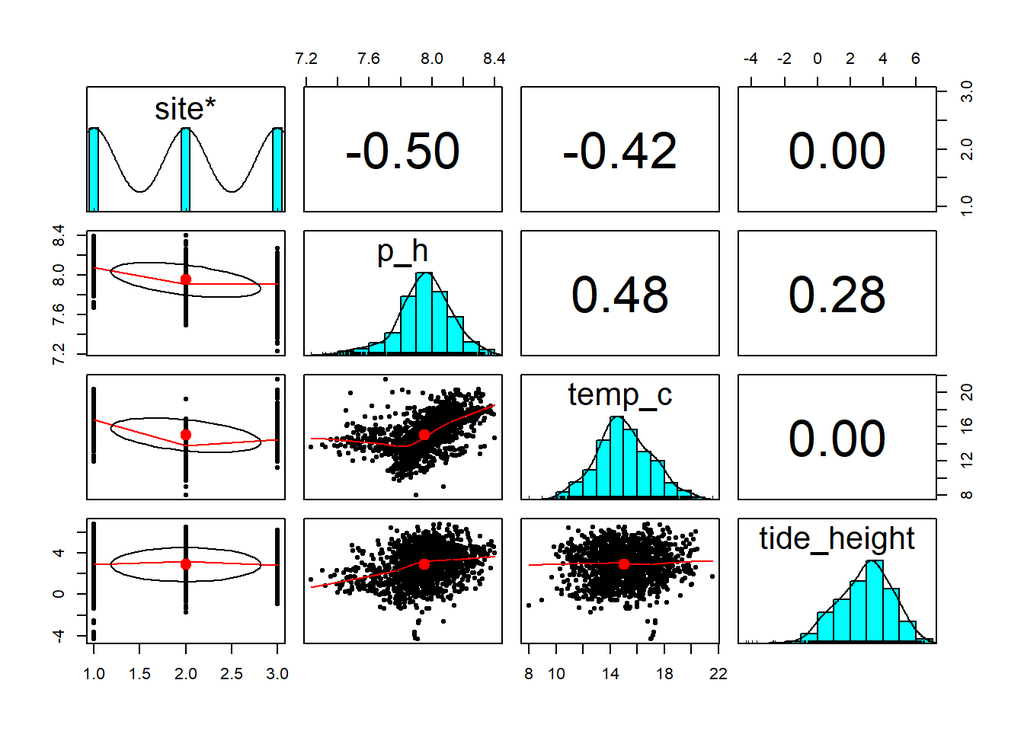

```r
pairs.panels(total)
```

```r
cor.test(total$p_h, total$temp_c, method = 'pearson', alternative = 'two.sided')
```

```
##
##  Pearson's product-moment correlation
##
## data:  total$p_h and total$temp_c
## t = 21.298, df = 1498, p-value < 2.2e-16
## alternative hypothesis: true correlation is not equal to 0
## 95 percent confidence interval:
##  0.4422804 0.5200262
## sample estimates:
##       cor
## 0.4821019
```

```r
cor.test(total$p_h, total$tide_height, method = 'pearson', alternative = 'two.sided')
```

```
##
##  Pearson's product-moment correlation
##
## data:  total$p_h and total$tide_height
## t = 11.45, df = 1498, p-value < 2.2e-16
## alternative hypothesis: true correlation is not equal to 0
## 95 percent confidence interval:
##  0.2364574 0.3295576
## sample estimates:
##       cor
## 0.2836759
```

The graph shows that the assumptions of bivariate normality are met. I use Pearson’s test to test the correlation. It shows that there exist significant correlation both between pH and temperature, and pH and tide height. The correlation coefficient between pH and temperature is 0.4821. The correlation coefficient between pH and tide height is 0.2836.

### Visualize the correlation: Take lompoc landing as an example

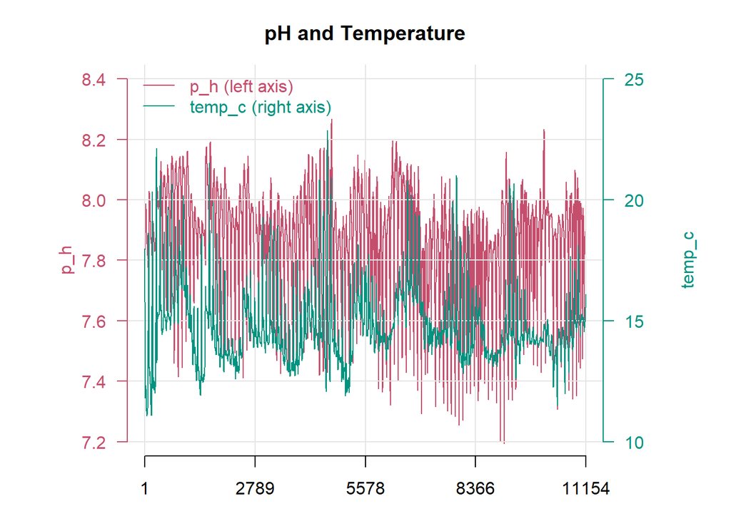

```r
lol$index<-1:nrow(lol)

with(lol, dualplot(x1 = index, y1 = p_h, y2 = temp_c,  main = 'pH and Temperature',
                colgrid = "grey90",ylim1 = c(7.2, 8.4), ylim2 = c(10, 25))) # dual y-axis plot
```

```r
l1<-cbind(1:nrow(lol), lol$p_h)
l2<-cbind(1:nrow(lol), lol$temp_c)
l3<-cbind(1:nrow(lol), lol$tide_height)
nrands = 10
# Calculates the wavelet coherence of pH and temperature
lol_wtc.AB = wtc(l1, l2, nrands = nrands)
```

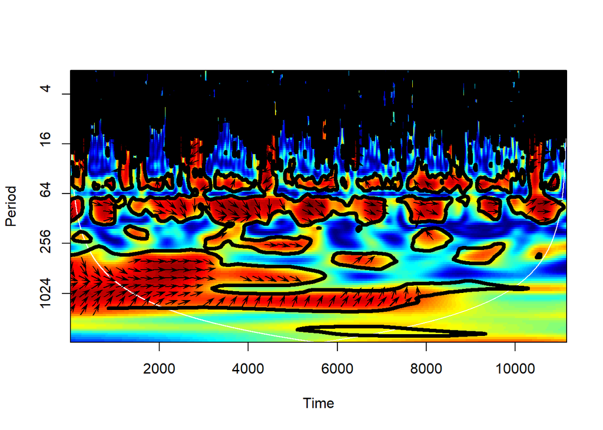

```r
plot(lol_wtc.AB, plot.phase = T) # wavelet coherence plot
```

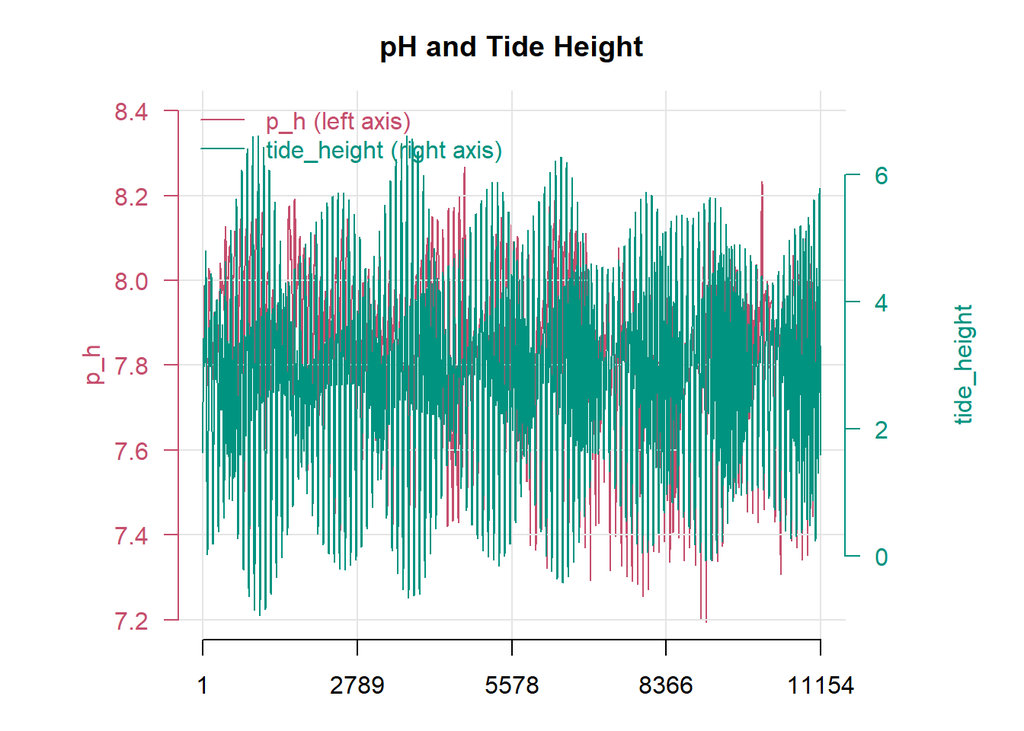

```r
with(lol, dualplot(x1 = index, y1 = p_h, y2 = tide_height, main = 'pH and Tide Height',
                   colgrid = "grey90",ylim1 = c(7.2, 8.4), ylim2 = c(-1, 7)))
```

```r
# Calculates the wavelet coherence of pH and tide height
lol_wtc.AB2 = wtc(l1, l3, nrands = nrands)
```

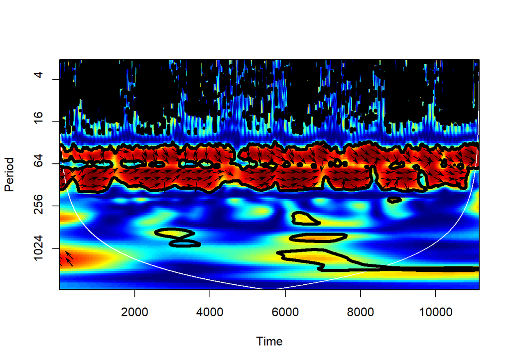

```r
plot(lol_wtc.AB2, plot.phase = T)
```